# DC Bike Share Demographic and Income levels

Joe Tudor, Richard Pandel, Demetrius Boone

Nov-17-2020

Loading packages we may use

```r
library(lubridate)
library(sf)
library(leaflet)
library(tmap)
library(tidyverse)
library(janitor)
library(readxl)
library(skimr)
library(summarytools)
library(ggplot2)
```

First We load the census datasets one for income and one for race demographic We then clean the names of the variables in the datasets

```r
incomefile <- read_csv("../data_raw/DCincome.csv") %>% clean_names()
demofile <- read_csv("../data_raw/DCdemographics.csv") %>% clean_names()
```

Only selecting the columns that we need and renaming them for clarity

```r
demofile2 <- demofile %>% select(namelsad=geographic_area_name, estimate_total, white=estimate_total_population_of_one_race_white, african_american=estimate_total_population_of_one_race_black_or_african_american, american_indian_alaska_native=estimate_total_population_of_one_race_american_indian_and_alaska_native, asian=estimate_total_population_of_one_race_asian_alone, hawaiin_pacific_islander=estimate_total_population_of_one_race_native_hawaiian_and_other_pacific_islander, other=estimate_total_population_of_one_race_some_other_race)
```

Creating a new percent variable for each ethnicity that represents the percent of a particular ethnicity per census tract. New dataframe demofile3 contains percentages of ethnicity over total population per each census tract.

```r
demofile3 <- demofile2 %>% mutate(perce_white=white/estimate_total,perce_african_american=african_american/estimate_total,perce_american_indian_alaska_native=american_indian_alaska_native/estimate_total,perce_asian=asian/estimate_total,perce_hawaiin_pacific_islander=hawaiin_pacific_islander/estimate_total,perce_other=other/estimate_total)

demofile3 = demofile3 %>% select(namelsad,estimate_total,perce_white,perce_african_american,perce_american_indian_alaska_native,perce_asian,perce_hawaiin_pacific_islander,perce_other)
```

Showing some summary statistics and plotting histograms for each ethnicity per census tract. Each histogram represents the amount of census tracts with the ranges of percent.

```r
summary(demofile3)
```

```
   namelsad         estimate_total  perce_white      perce_african_american
 Length:179         Min.   :  60   Min.   :0.00000   Min.   :0.0000
 Class :character   1st Qu.:2849   1st Qu.:0.07199   1st Qu.:0.1304
 Mode  :character   Median :3502   Median :0.35599   Median :0.4777
                    Mean   :3824   Mean   :0.39168   Mean   :0.4961
                    3rd Qu.:4717   3rd Qu.:0.70954   3rd Qu.:0.8554
                    Max.   :7805   Max.   :1.00000   Max.   :1.0000
 perce_american_indian_alaska_native  perce_asian       perce_hawaiin_pacific_islander
 Min.   :0.000000                    Min.   :0.000000   Min.   :0.0000000
 1st Qu.:0.000000                    1st Qu.:0.003937   1st Qu.:0.0000000
 Median :0.000000                    Median :0.025700   Median :0.0000000
 Mean   :0.002912                    Mean   :0.035902   Mean   :0.0005635
 3rd Qu.:0.002909                    3rd Qu.:0.058022   3rd Qu.:0.0000000
 Max.   :0.083141                    Max.   :0.188892   Max.   :0.0199317
  perce_other
 Min.   :0.000000
 1st Qu.:0.005838
 Median :0.021159
 Mean   :0.044207
 3rd Qu.:0.051547
 Max.   :0.312384
```

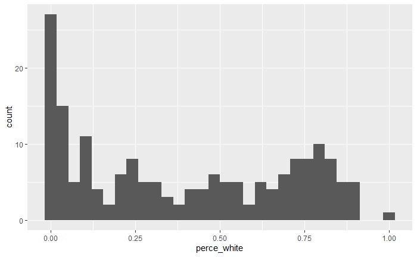

```r
demofile3 %>% ggplot(aes(x=perce_white)) +
  geom_histogram()
```

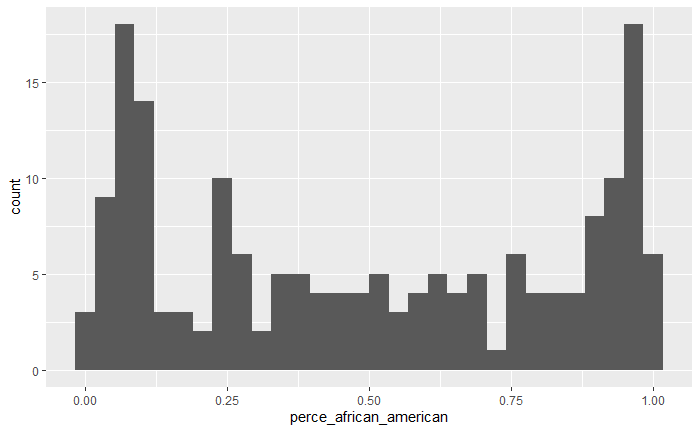

```r
demofile3 %>% ggplot(aes(x=perce_african_american)) +
  geom_histogram()
```

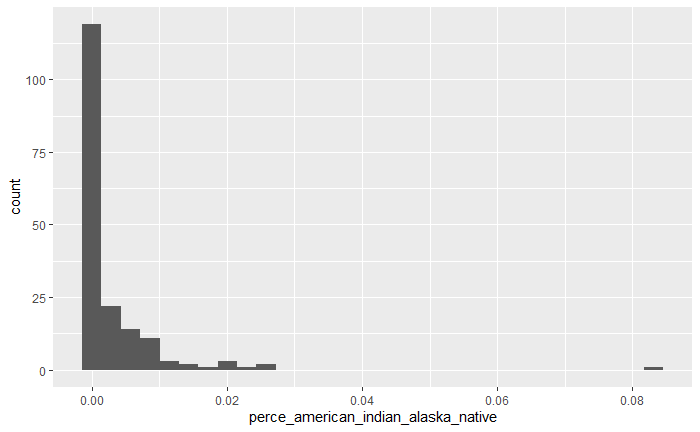

```r
demofile3 %>% ggplot(aes(x=perce_american_indian_alaska_native)) +
  geom_histogram()
```

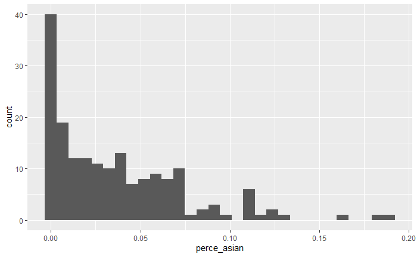

```r
demofile3 %>% ggplot(aes(x=perce_asian)) +
  geom_histogram()
```

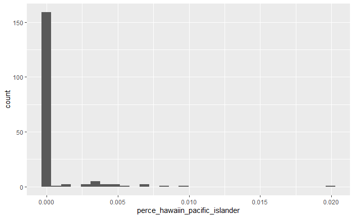

```r
demofile3 %>% ggplot(aes(x=perce_hawaiin_pacific_islander)) +
  geom_histogram()
```

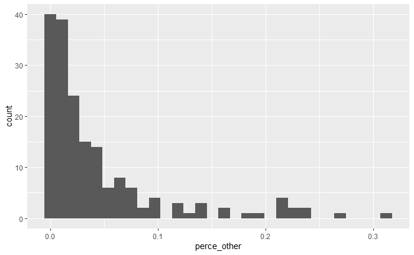

```r
demofile3 %>% ggplot(aes(x=perce_other)) +
  geom_histogram()
```

**Mapping** Read shapefile data

```r
census_sf =  st_read("../data_raw/tl_2019_11_tract/tl_2019_11_tract.shp") %>% clean_names()
```

```r
tmap_mode("view")
```

```
tmap mode set to interactive viewing
```

```r
tm_shape(census_sf)+tm_polygons(alpha=.3)
```

[interactive chart not shown]

*Then you should be able to cross reference the data by tract on the map. We tried to plot the demographic and income data on the map for each census tract but could not figure out how.*